# Berlin

## Neueinstellungen

## Entwicklung

| 5007 Airbnb Wohnungen eingestellt | 73 |
| --- | --- |

Seit 02.01.2018 wurden in Berlin:

## Entwicklung

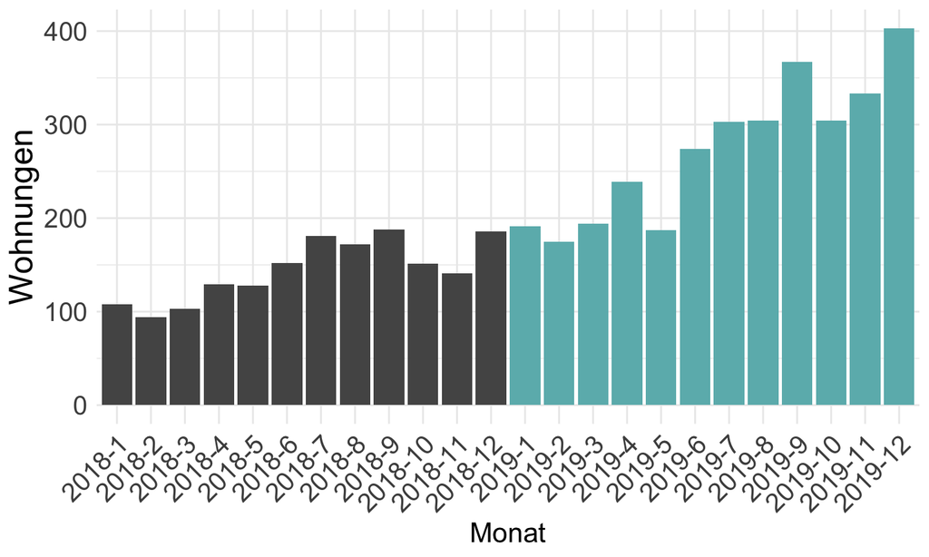

Figure 1. Neueinstellungen pro Monat

## Stadteile

- Meisten Neueinstellungen: Friedrichshain-Kreuzberg
- Wenigste Neueinstellungen: Marzahn - Hellersdorf
- Grössten Reduktion mit -13.3% in Marzahn - Hellersdorf
- Grösster Zuwachs mit 137.8% in Treptow - Köpenick

## Stadteile

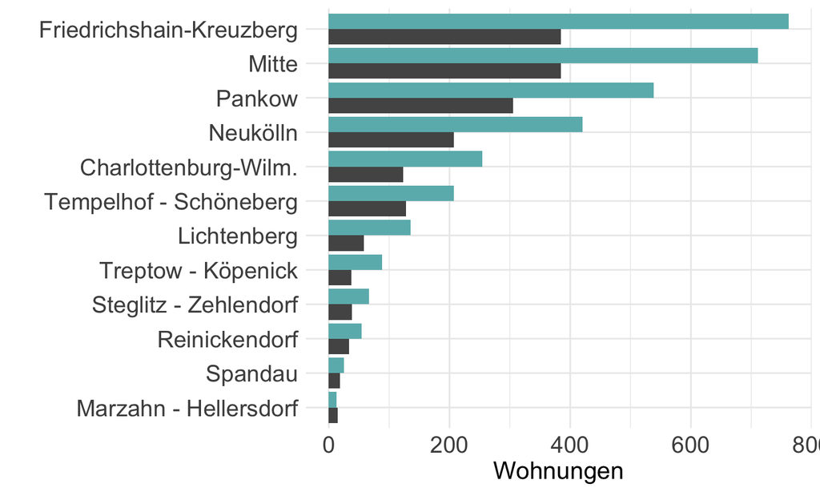

Figure 2. Neueinstellungen pro Bezirk

## Preis

## Einfluss der Ausstattung

- Durchschnittliche Preis der Neueinstellungen 80.8 €
- Anstieg der Preise um 1.7%
- Grössten Unterschied im Preis Check_in_24h (72.9)
- Kleinster Unterschied im Preis Küche (-88.9)

## Einfluss der Ausstattung

Tabelle 1. Ausstattung und Einfluss auf den Preis

|  | Preis Nicht-vorh. | Preis vorh. | Differenz | Prozent vorh. |
| --- | --- | --- | --- | --- |
| Check_in_24h | 79.9 | 152.8 | 72.9 | 1.3 |
| TV | 62.5 | 100.6 | 38.2 | 48.2 |
| Wifi | 56.3 | 81.7 | 25.3 | 96.7 |
| Terrasse_Balkon | 76.1 | 92.9 | 16.8 | 28 |
| Geschirrspüler | 78.5 | 85 | 6.5 | 36.3 |
| Kaffeemaschine | 80.5 | 81.2 | 0.7 | 50.5 |
| Küche | 162.3 | 73.4 | -88.9 | 91.7 |

**Der stark negative Effekt der Küche überrascht. Er könnte durch die Art der Unterkunft moderiert werden, gegeben dass auch Hotels im Angebot enthalten sind.**

## Regressionsmodell

Tabelle 2. Regression des Preises auf die Ausstattung.

Preis

Predictors

Estimates

CI

(Intercept)

90.08 ***

68.95 – 111.21

HotelTRUE

437.34 ***

384.88 – 489.79

KücheTRUE

-37.95 ***

-59.50 – -16.40

TVTRUE

28.07 ***

16.67 – 39.47

Terrasse_BalkonTRUE

20.71 **

8.06 – 33.35

Check_in_24hTRUE

42.11

-7.81 – 92.02

Observations

5007

R<sup>2</sup> / R<sup>2</sup> adjusted

0.074 / 0.073

- p<0.05 ** p<0.01 *** p<0.001

**Der Anteil von Hotels ist von 1.1% im Jahre 2018 auf 1.4% im Jahre 2019 gestiegen. Es liegt nahe, dass der Anstieg im Anteil der Hotels, den Anstieg der Objektpreise verursacht hat.**